# Risk Factor Analysis

## Outcome Variable

**Outcome Variable:** stunted

## Predictor Variables

**Intervention Variable:** brthmon

**Adjustment Set:**

unadjusted

## Stratifying Variables

The analysis was stratified on these variable(s):

- agecat
- studyid
- country

## Data Summary

| agecat | studyid | country | A | n | nA | nAY0 | nAY1 |
| --- | --- | --- | --- | --- | --- | --- | --- |
| Birth | ki0047075b-MAL-ED | BANGLADESH | 1 | 257 | 20 | 16 | 4 |
| Birth | ki0047075b-MAL-ED | BANGLADESH | 2 | 257 | 25 | 19 | 6 |
| Birth | ki0047075b-MAL-ED | BANGLADESH | 3 | 257 | 25 | 18 | 7 |
| Birth | ki0047075b-MAL-ED | BANGLADESH | 4 | 257 | 21 | 21 | 0 |
| Birth | ki0047075b-MAL-ED | BANGLADESH | 5 | 257 | 21 | 16 | 5 |
| Birth | ki0047075b-MAL-ED | BANGLADESH | 6 | 257 | 11 | 7 | 4 |
| Birth | ki0047075b-MAL-ED | BANGLADESH | 7 | 257 | 20 | 15 | 5 |
| Birth | ki0047075b-MAL-ED | BANGLADESH | 8 | 257 | 26 | 21 | 5 |
| Birth | ki0047075b-MAL-ED | BANGLADESH | 9 | 257 | 21 | 19 | 2 |
| Birth | ki0047075b-MAL-ED | BANGLADESH | 10 | 257 | 25 | 20 | 5 |
| Birth | ki0047075b-MAL-ED | BANGLADESH | 11 | 257 | 15 | 13 | 2 |
| Birth | ki0047075b-MAL-ED | BANGLADESH | 12 | 257 | 27 | 25 | 2 |
| Birth | ki0047075b-MAL-ED | BRAZIL | 1 | 191 | 11 | 10 | 1 |
| Birth | ki0047075b-MAL-ED | BRAZIL | 2 | 191 | 19 | 17 | 2 |
| Birth | ki0047075b-MAL-ED | BRAZIL | 3 | 191 | 18 | 17 | 1 |
| Birth | ki0047075b-MAL-ED | BRAZIL | 4 | 191 | 9 | 9 | 0 |
| Birth | ki0047075b-MAL-ED | BRAZIL | 5 | 191 | 18 | 15 | 3 |
| Birth | ki0047075b-MAL-ED | BRAZIL | 6 | 191 | 8 | 6 | 2 |
| Birth | ki0047075b-MAL-ED | BRAZIL | 7 | 191 | 16 | 13 | 3 |
| Birth | ki0047075b-MAL-ED | BRAZIL | 8 | 191 | 18 | 16 | 2 |
| Birth | ki0047075b-MAL-ED | BRAZIL | 9 | 191 | 29 | 25 | 4 |
| Birth | ki0047075b-MAL-ED | BRAZIL | 10 | 191 | 17 | 17 | 0 |
| Birth | ki0047075b-MAL-ED | BRAZIL | 11 | 191 | 18 | 18 | 0 |
| Birth | ki0047075b-MAL-ED | BRAZIL | 12 | 191 | 10 | 7 | 3 |
| Birth | ki0047075b-MAL-ED | INDIA | 1 | 206 | 16 | 15 | 1 |
| Birth | ki0047075b-MAL-ED | INDIA | 2 | 206 | 16 | 16 | 0 |
| Birth | ki0047075b-MAL-ED | INDIA | 3 | 206 | 21 | 19 | 2 |
| Birth | ki0047075b-MAL-ED | INDIA | 4 | 206 | 14 | 12 | 2 |
| Birth | ki0047075b-MAL-ED | INDIA | 5 | 206 | 7 | 6 | 1 |
| Birth | ki0047075b-MAL-ED | INDIA | 6 | 206 | 18 | 17 | 1 |

[output cut: 2154 more lines]

The following strata were considered:

- agecat: 12 months, studyid: ki0047075b-MAL-ED, country: BANGLADESH
- agecat: 12 months, studyid: ki0047075b-MAL-ED, country: BRAZIL
- agecat: 12 months, studyid: ki0047075b-MAL-ED, country: INDIA
- agecat: 12 months, studyid: ki0047075b-MAL-ED, country: NEPAL
- agecat: 12 months, studyid: ki0047075b-MAL-ED, country: PERU
- agecat: 12 months, studyid: ki0047075b-MAL-ED, country: SOUTH AFRICA
- agecat: 12 months, studyid: ki0047075b-MAL-ED, country: TANZANIA, UNITED REPUBLIC OF
- agecat: 12 months, studyid: ki1000108-CMC-V-BCS-2002, country: INDIA
- agecat: 12 months, studyid: ki1000108-IRC, country: INDIA
- agecat: 12 months, studyid: ki1000109-EE, country: PAKISTAN
- agecat: 12 months, studyid: ki1000109-ResPak, country: PAKISTAN
- agecat: 12 months, studyid: ki1000304b-SAS-CompFeed, country: INDIA
- agecat: 12 months, studyid: ki1000304b-SAS-FoodSuppl, country: INDIA
- agecat: 12 months, studyid: ki1017093-NIH-Birth, country: BANGLADESH
- agecat: 12 months, studyid: ki1066203-TanzaniaChild2, country: TANZANIA, UNITED REPUBLIC OF
- agecat: 12 months, studyid: ki1101329-Keneba, country: GAMBIA
- agecat: 12 months, studyid: ki1112895-Guatemala BSC, country: GUATEMALA
- agecat: 12 months, studyid: ki1113344-GMS-Nepal, country: NEPAL
- agecat: 12 months, studyid: ki1114097-CMIN, country: BANGLADESH
- agecat: 12 months, studyid: ki1114097-CMIN, country: BRAZIL
- agecat: 12 months, studyid: ki1114097-CMIN, country: GUINEA-BISSAU
- agecat: 12 months, studyid: ki1114097-CMIN, country: PERU
- agecat: 12 months, studyid: ki1114097-CONTENT, country: PERU
- agecat: 12 months, studyid: ki1119695-PROBIT, country: BELARUS
- agecat: 12 months, studyid: ki1126311-ZVITAMBO, country: ZIMBABWE
- agecat: 12 months, studyid: ki1148112-LCNI-5, country: MALAWI
- agecat: 12 months, studyid: kiGH5241-JiVitA-3, country: BANGLADESH
- agecat: 12 months, studyid: kiGH5241-JiVitA-4, country: BANGLADESH
- agecat: 18 months, studyid: ki0047075b-MAL-ED, country: BANGLADESH
- agecat: 18 months, studyid: ki0047075b-MAL-ED, country: BRAZIL
- agecat: 18 months, studyid: ki0047075b-MAL-ED, country: INDIA
- agecat: 18 months, studyid: ki0047075b-MAL-ED, country: NEPAL
- agecat: 18 months, studyid: ki0047075b-MAL-ED, country: PERU
- agecat: 18 months, studyid: ki0047075b-MAL-ED, country: SOUTH AFRICA
- agecat: 18 months, studyid: ki0047075b-MAL-ED, country: TANZANIA, UNITED REPUBLIC OF
- agecat: 18 months, studyid: ki1000108-CMC-V-BCS-2002, country: INDIA
- agecat: 18 months, studyid: ki1000108-IRC, country: INDIA
- agecat: 18 months, studyid: ki1000109-EE, country: PAKISTAN
- agecat: 18 months, studyid: ki1000109-ResPak, country: PAKISTAN
- agecat: 18 months, studyid: ki1000304b-SAS-CompFeed, country: INDIA
- agecat: 18 months, studyid: ki1000304b-SAS-FoodSuppl, country: INDIA
- agecat: 18 months, studyid: ki1017093-NIH-Birth, country: BANGLADESH
- agecat: 18 months, studyid: ki1066203-TanzaniaChild2, country: TANZANIA, UNITED REPUBLIC OF
- agecat: 18 months, studyid: ki1101329-Keneba, country: GAMBIA
- agecat: 18 months, studyid: ki1112895-iLiNS-Zinc, country: BURKINA FASO
- agecat: 18 months, studyid: ki1113344-GMS-Nepal, country: NEPAL
- agecat: 18 months, studyid: ki1114097-CMIN, country: BANGLADESH
- agecat: 18 months, studyid: ki1114097-CMIN, country: BRAZIL
- agecat: 18 months, studyid: ki1114097-CMIN, country: GUINEA-BISSAU
- agecat: 18 months, studyid: ki1114097-CMIN, country: PERU
- agecat: 18 months, studyid: ki1114097-CONTENT, country: PERU
- agecat: 18 months, studyid: ki1119695-PROBIT, country: BELARUS
- agecat: 18 months, studyid: ki1126311-ZVITAMBO, country: ZIMBABWE
- agecat: 18 months, studyid: ki1148112-LCNI-5, country: MALAWI
- agecat: 18 months, studyid: kiGH5241-JiVitA-4, country: BANGLADESH
- agecat: 24 months, studyid: ki0047075b-MAL-ED, country: BANGLADESH
- agecat: 24 months, studyid: ki0047075b-MAL-ED, country: BRAZIL
- agecat: 24 months, studyid: ki0047075b-MAL-ED, country: INDIA
- agecat: 24 months, studyid: ki0047075b-MAL-ED, country: NEPAL
- agecat: 24 months, studyid: ki0047075b-MAL-ED, country: PERU
- agecat: 24 months, studyid: ki0047075b-MAL-ED, country: SOUTH AFRICA
- agecat: 24 months, studyid: ki0047075b-MAL-ED, country: TANZANIA, UNITED REPUBLIC OF
- agecat: 24 months, studyid: ki1000108-CMC-V-BCS-2002, country: INDIA
- agecat: 24 months, studyid: ki1000108-IRC, country: INDIA
- agecat: 24 months, studyid: ki1017093-NIH-Birth, country: BANGLADESH
- agecat: 24 months, studyid: ki1066203-TanzaniaChild2, country: TANZANIA, UNITED REPUBLIC OF
- agecat: 24 months, studyid: ki1101329-Keneba, country: GAMBIA
- agecat: 24 months, studyid: ki1113344-GMS-Nepal, country: NEPAL
- agecat: 24 months, studyid: ki1114097-CMIN, country: BANGLADESH
- agecat: 24 months, studyid: ki1114097-CMIN, country: GUINEA-BISSAU
- agecat: 24 months, studyid: ki1114097-CMIN, country: PERU
- agecat: 24 months, studyid: ki1114097-CONTENT, country: PERU
- agecat: 24 months, studyid: ki1119695-PROBIT, country: BELARUS
- agecat: 24 months, studyid: ki1126311-ZVITAMBO, country: ZIMBABWE
- agecat: 24 months, studyid: ki1148112-LCNI-5, country: MALAWI
- agecat: 24 months, studyid: kiGH5241-JiVitA-3, country: BANGLADESH
- agecat: 24 months, studyid: kiGH5241-JiVitA-4, country: BANGLADESH
- agecat: 3 months, studyid: ki0047075b-MAL-ED, country: BANGLADESH
- agecat: 3 months, studyid: ki0047075b-MAL-ED, country: BRAZIL
- agecat: 3 months, studyid: ki0047075b-MAL-ED, country: INDIA
- agecat: 3 months, studyid: ki0047075b-MAL-ED, country: NEPAL
- agecat: 3 months, studyid: ki0047075b-MAL-ED, country: PERU
- agecat: 3 months, studyid: ki0047075b-MAL-ED, country: SOUTH AFRICA
- agecat: 3 months, studyid: ki0047075b-MAL-ED, country: TANZANIA, UNITED REPUBLIC OF
- agecat: 3 months, studyid: ki1000108-CMC-V-BCS-2002, country: INDIA
- agecat: 3 months, studyid: ki1000108-IRC, country: INDIA
- agecat: 3 months, studyid: ki1000109-EE, country: PAKISTAN
- agecat: 3 months, studyid: ki1000109-ResPak, country: PAKISTAN
- agecat: 3 months, studyid: ki1000304b-SAS-CompFeed, country: INDIA
- agecat: 3 months, studyid: ki1000304b-SAS-FoodSuppl, country: INDIA
- agecat: 3 months, studyid: ki1017093-NIH-Birth, country: BANGLADESH
- agecat: 3 months, studyid: ki1066203-TanzaniaChild2, country: TANZANIA, UNITED REPUBLIC OF
- agecat: 3 months, studyid: ki1101329-Keneba, country: GAMBIA
- agecat: 3 months, studyid: ki1112895-Guatemala BSC, country: GUATEMALA
- agecat: 3 months, studyid: ki1113344-GMS-Nepal, country: NEPAL
- agecat: 3 months, studyid: ki1114097-CMIN, country: BANGLADESH
- agecat: 3 months, studyid: ki1114097-CMIN, country: BRAZIL
- agecat: 3 months, studyid: ki1114097-CMIN, country: GUINEA-BISSAU
- agecat: 3 months, studyid: ki1114097-CMIN, country: PERU
- agecat: 3 months, studyid: ki1114097-CONTENT, country: PERU
- agecat: 3 months, studyid: ki1119695-PROBIT, country: BELARUS
- agecat: 3 months, studyid: ki1126311-ZVITAMBO, country: ZIMBABWE
- agecat: 3 months, studyid: kiGH5241-JiVitA-3, country: BANGLADESH
- agecat: 3 months, studyid: kiGH5241-JiVitA-4, country: BANGLADESH
- agecat: 6 months, studyid: ki0047075b-MAL-ED, country: BANGLADESH
- agecat: 6 months, studyid: ki0047075b-MAL-ED, country: BRAZIL
- agecat: 6 months, studyid: ki0047075b-MAL-ED, country: INDIA
- agecat: 6 months, studyid: ki0047075b-MAL-ED, country: NEPAL
- agecat: 6 months, studyid: ki0047075b-MAL-ED, country: PERU
- agecat: 6 months, studyid: ki0047075b-MAL-ED, country: SOUTH AFRICA
- agecat: 6 months, studyid: ki0047075b-MAL-ED, country: TANZANIA, UNITED REPUBLIC OF
- agecat: 6 months, studyid: ki1000108-CMC-V-BCS-2002, country: INDIA
- agecat: 6 months, studyid: ki1000108-IRC, country: INDIA
- agecat: 6 months, studyid: ki1000109-EE, country: PAKISTAN
- agecat: 6 months, studyid: ki1000109-ResPak, country: PAKISTAN
- agecat: 6 months, studyid: ki1000304b-SAS-CompFeed, country: INDIA
- agecat: 6 months, studyid: ki1000304b-SAS-FoodSuppl, country: INDIA
- agecat: 6 months, studyid: ki1017093-NIH-Birth, country: BANGLADESH
- agecat: 6 months, studyid: ki1066203-TanzaniaChild2, country: TANZANIA, UNITED REPUBLIC OF
- agecat: 6 months, studyid: ki1101329-Keneba, country: GAMBIA
- agecat: 6 months, studyid: ki1112895-Guatemala BSC, country: GUATEMALA
- agecat: 6 months, studyid: ki1113344-GMS-Nepal, country: NEPAL
- agecat: 6 months, studyid: ki1114097-CMIN, country: BANGLADESH
- agecat: 6 months, studyid: ki1114097-CMIN, country: BRAZIL
- agecat: 6 months, studyid: ki1114097-CMIN, country: GUINEA-BISSAU
- agecat: 6 months, studyid: ki1114097-CMIN, country: PERU
- agecat: 6 months, studyid: ki1114097-CONTENT, country: PERU
- agecat: 6 months, studyid: ki1119695-PROBIT, country: BELARUS
- agecat: 6 months, studyid: ki1126311-ZVITAMBO, country: ZIMBABWE
- agecat: 6 months, studyid: ki1148112-LCNI-5, country: MALAWI
- agecat: 6 months, studyid: kiGH5241-JiVitA-3, country: BANGLADESH
- agecat: 6 months, studyid: kiGH5241-JiVitA-4, country: BANGLADESH
- agecat: 9 months, studyid: ki0047075b-MAL-ED, country: BANGLADESH
- agecat: 9 months, studyid: ki0047075b-MAL-ED, country: BRAZIL
- agecat: 9 months, studyid: ki0047075b-MAL-ED, country: INDIA
- agecat: 9 months, studyid: ki0047075b-MAL-ED, country: NEPAL
- agecat: 9 months, studyid: ki0047075b-MAL-ED, country: PERU
- agecat: 9 months, studyid: ki0047075b-MAL-ED, country: SOUTH AFRICA
- agecat: 9 months, studyid: ki0047075b-MAL-ED, country: TANZANIA, UNITED REPUBLIC OF
- agecat: 9 months, studyid: ki1000108-CMC-V-BCS-2002, country: INDIA
- agecat: 9 months, studyid: ki1000108-IRC, country: INDIA
- agecat: 9 months, studyid: ki1000109-EE, country: PAKISTAN
- agecat: 9 months, studyid: ki1000109-ResPak, country: PAKISTAN
- agecat: 9 months, studyid: ki1000304b-SAS-CompFeed, country: INDIA
- agecat: 9 months, studyid: ki1000304b-SAS-FoodSuppl, country: INDIA
- agecat: 9 months, studyid: ki1017093-NIH-Birth, country: BANGLADESH
- agecat: 9 months, studyid: ki1066203-TanzaniaChild2, country: TANZANIA, UNITED REPUBLIC OF
- agecat: 9 months, studyid: ki1101329-Keneba, country: GAMBIA
- agecat: 9 months, studyid: ki1112895-Guatemala BSC, country: GUATEMALA
- agecat: 9 months, studyid: ki1112895-iLiNS-Zinc, country: BURKINA FASO
- agecat: 9 months, studyid: ki1113344-GMS-Nepal, country: NEPAL
- agecat: 9 months, studyid: ki1114097-CMIN, country: BANGLADESH
- agecat: 9 months, studyid: ki1114097-CMIN, country: BRAZIL
- agecat: 9 months, studyid: ki1114097-CMIN, country: GUINEA-BISSAU
- agecat: 9 months, studyid: ki1114097-CMIN, country: PERU
- agecat: 9 months, studyid: ki1114097-CONTENT, country: PERU
- agecat: 9 months, studyid: ki1119695-PROBIT, country: BELARUS
- agecat: 9 months, studyid: ki1126311-ZVITAMBO, country: ZIMBABWE
- agecat: 9 months, studyid: ki1148112-LCNI-5, country: MALAWI
- agecat: 9 months, studyid: kiGH5241-JiVitA-4, country: BANGLADESH
- agecat: Birth, studyid: ki0047075b-MAL-ED, country: BANGLADESH
- agecat: Birth, studyid: ki0047075b-MAL-ED, country: BRAZIL
- agecat: Birth, studyid: ki0047075b-MAL-ED, country: INDIA
- agecat: Birth, studyid: ki0047075b-MAL-ED, country: NEPAL
- agecat: Birth, studyid: ki0047075b-MAL-ED, country: PERU
- agecat: Birth, studyid: ki0047075b-MAL-ED, country: SOUTH AFRICA
- agecat: Birth, studyid: ki0047075b-MAL-ED, country: TANZANIA, UNITED REPUBLIC OF
- agecat: Birth, studyid: ki1000108-CMC-V-BCS-2002, country: INDIA
- agecat: Birth, studyid: ki1000108-IRC, country: INDIA
- agecat: Birth, studyid: ki1000109-EE, country: PAKISTAN
- agecat: Birth, studyid: ki1000109-ResPak, country: PAKISTAN
- agecat: Birth, studyid: ki1000304b-SAS-CompFeed, country: INDIA
- agecat: Birth, studyid: ki1017093-NIH-Birth, country: BANGLADESH
- agecat: Birth, studyid: ki1101329-Keneba, country: GAMBIA
- agecat: Birth, studyid: ki1114097-CMIN, country: BANGLADESH
- agecat: Birth, studyid: ki1114097-CMIN, country: BRAZIL
- agecat: Birth, studyid: ki1114097-CMIN, country: PERU
- agecat: Birth, studyid: ki1114097-CONTENT, country: PERU
- agecat: Birth, studyid: ki1119695-PROBIT, country: BELARUS
- agecat: Birth, studyid: ki1126311-ZVITAMBO, country: ZIMBABWE
- agecat: Birth, studyid: kiGH5241-JiVitA-3, country: BANGLADESH
- agecat: Birth, studyid: kiGH5241-JiVitA-4, country: BANGLADESH

### Dropped Strata

Some strata were dropped due to rare outcomes:

- agecat: Birth, studyid: ki0047075b-MAL-ED, country: BANGLADESH
- agecat: Birth, studyid: ki0047075b-MAL-ED, country: BRAZIL
- agecat: Birth, studyid: ki0047075b-MAL-ED, country: INDIA
- agecat: Birth, studyid: ki0047075b-MAL-ED, country: NEPAL
- agecat: Birth, studyid: ki0047075b-MAL-ED, country: PERU
- agecat: Birth, studyid: ki0047075b-MAL-ED, country: SOUTH AFRICA
- agecat: Birth, studyid: ki0047075b-MAL-ED, country: TANZANIA, UNITED REPUBLIC OF
- agecat: Birth, studyid: ki1000108-CMC-V-BCS-2002, country: INDIA
- agecat: Birth, studyid: ki1000108-IRC, country: INDIA
- agecat: Birth, studyid: ki1000109-EE, country: PAKISTAN
- agecat: Birth, studyid: ki1000109-ResPak, country: PAKISTAN
- agecat: Birth, studyid: ki1000304b-SAS-CompFeed, country: INDIA
- agecat: Birth, studyid: ki1017093-NIH-Birth, country: BANGLADESH
- agecat: Birth, studyid: ki1101329-Keneba, country: GAMBIA
- agecat: Birth, studyid: ki1114097-CMIN, country: BANGLADESH
- agecat: Birth, studyid: ki1114097-CMIN, country: BRAZIL
- agecat: Birth, studyid: ki1114097-CMIN, country: PERU
- agecat: Birth, studyid: ki1114097-CONTENT, country: PERU
- agecat: Birth, studyid: ki1119695-PROBIT, country: BELARUS
- agecat: Birth, studyid: kiGH5241-JiVitA-4, country: BANGLADESH
- agecat: 3 months, studyid: ki0047075b-MAL-ED, country: BANGLADESH
- agecat: 3 months, studyid: ki0047075b-MAL-ED, country: BRAZIL
- agecat: 3 months, studyid: ki0047075b-MAL-ED, country: INDIA
- agecat: 3 months, studyid: ki0047075b-MAL-ED, country: NEPAL
- agecat: 3 months, studyid: ki0047075b-MAL-ED, country: PERU
- agecat: 3 months, studyid: ki0047075b-MAL-ED, country: SOUTH AFRICA
- agecat: 3 months, studyid: ki0047075b-MAL-ED, country: TANZANIA, UNITED REPUBLIC OF
- agecat: 3 months, studyid: ki1000108-CMC-V-BCS-2002, country: INDIA
- agecat: 3 months, studyid: ki1000108-IRC, country: INDIA
- agecat: 3 months, studyid: ki1000109-EE, country: PAKISTAN
- agecat: 3 months, studyid: ki1000109-ResPak, country: PAKISTAN
- agecat: 3 months, studyid: ki1000304b-SAS-CompFeed, country: INDIA
- agecat: 3 months, studyid: ki1000304b-SAS-FoodSuppl, country: INDIA
- agecat: 3 months, studyid: ki1112895-Guatemala BSC, country: GUATEMALA
- agecat: 3 months, studyid: ki1113344-GMS-Nepal, country: NEPAL
- agecat: 3 months, studyid: ki1114097-CMIN, country: BANGLADESH
- agecat: 3 months, studyid: ki1114097-CMIN, country: BRAZIL
- agecat: 3 months, studyid: ki1114097-CMIN, country: GUINEA-BISSAU
- agecat: 3 months, studyid: ki1114097-CMIN, country: PERU
- agecat: 3 months, studyid: ki1114097-CONTENT, country: PERU
- agecat: 3 months, studyid: kiGH5241-JiVitA-4, country: BANGLADESH
- agecat: 6 months, studyid: ki0047075b-MAL-ED, country: BANGLADESH
- agecat: 6 months, studyid: ki0047075b-MAL-ED, country: BRAZIL
- agecat: 6 months, studyid: ki0047075b-MAL-ED, country: INDIA
- agecat: 6 months, studyid: ki0047075b-MAL-ED, country: NEPAL
- agecat: 6 months, studyid: ki0047075b-MAL-ED, country: PERU
- agecat: 6 months, studyid: ki0047075b-MAL-ED, country: SOUTH AFRICA
- agecat: 6 months, studyid: ki0047075b-MAL-ED, country: TANZANIA, UNITED REPUBLIC OF
- agecat: 6 months, studyid: ki1000109-EE, country: PAKISTAN
- agecat: 6 months, studyid: ki1000109-ResPak, country: PAKISTAN
- agecat: 6 months, studyid: ki1000304b-SAS-CompFeed, country: INDIA
- agecat: 6 months, studyid: ki1000304b-SAS-FoodSuppl, country: INDIA
- agecat: 6 months, studyid: ki1112895-Guatemala BSC, country: GUATEMALA
- agecat: 6 months, studyid: ki1113344-GMS-Nepal, country: NEPAL
- agecat: 6 months, studyid: ki1114097-CMIN, country: BANGLADESH
- agecat: 6 months, studyid: ki1114097-CMIN, country: BRAZIL
- agecat: 6 months, studyid: ki1114097-CMIN, country: GUINEA-BISSAU
- agecat: 6 months, studyid: ki1114097-CMIN, country: PERU
- agecat: 6 months, studyid: ki1114097-CONTENT, country: PERU
- agecat: 6 months, studyid: kiGH5241-JiVitA-4, country: BANGLADESH
- agecat: 9 months, studyid: ki0047075b-MAL-ED, country: BANGLADESH
- agecat: 9 months, studyid: ki0047075b-MAL-ED, country: BRAZIL
- agecat: 9 months, studyid: ki0047075b-MAL-ED, country: INDIA
- agecat: 9 months, studyid: ki0047075b-MAL-ED, country: NEPAL
- agecat: 9 months, studyid: ki0047075b-MAL-ED, country: PERU
- agecat: 9 months, studyid: ki0047075b-MAL-ED, country: SOUTH AFRICA
- agecat: 9 months, studyid: ki0047075b-MAL-ED, country: TANZANIA, UNITED REPUBLIC OF
- agecat: 9 months, studyid: ki1000108-CMC-V-BCS-2002, country: INDIA
- agecat: 9 months, studyid: ki1000109-EE, country: PAKISTAN
- agecat: 9 months, studyid: ki1000109-ResPak, country: PAKISTAN
- agecat: 9 months, studyid: ki1000304b-SAS-CompFeed, country: INDIA
- agecat: 9 months, studyid: ki1000304b-SAS-FoodSuppl, country: INDIA
- agecat: 9 months, studyid: ki1112895-Guatemala BSC, country: GUATEMALA
- agecat: 9 months, studyid: ki1113344-GMS-Nepal, country: NEPAL
- agecat: 9 months, studyid: ki1114097-CMIN, country: BANGLADESH
- agecat: 9 months, studyid: ki1114097-CMIN, country: BRAZIL
- agecat: 9 months, studyid: ki1114097-CMIN, country: GUINEA-BISSAU
- agecat: 9 months, studyid: ki1114097-CMIN, country: PERU
- agecat: 9 months, studyid: ki1114097-CONTENT, country: PERU
- agecat: 9 months, studyid: kiGH5241-JiVitA-4, country: BANGLADESH
- agecat: 12 months, studyid: ki0047075b-MAL-ED, country: BANGLADESH
- agecat: 12 months, studyid: ki0047075b-MAL-ED, country: BRAZIL
- agecat: 12 months, studyid: ki0047075b-MAL-ED, country: INDIA
- agecat: 12 months, studyid: ki0047075b-MAL-ED, country: NEPAL
- agecat: 12 months, studyid: ki0047075b-MAL-ED, country: PERU
- agecat: 12 months, studyid: ki0047075b-MAL-ED, country: SOUTH AFRICA
- agecat: 12 months, studyid: ki0047075b-MAL-ED, country: TANZANIA, UNITED REPUBLIC OF
- agecat: 12 months, studyid: ki1000108-CMC-V-BCS-2002, country: INDIA
- agecat: 12 months, studyid: ki1000109-EE, country: PAKISTAN
- agecat: 12 months, studyid: ki1000109-ResPak, country: PAKISTAN
- agecat: 12 months, studyid: ki1000304b-SAS-CompFeed, country: INDIA
- agecat: 12 months, studyid: ki1000304b-SAS-FoodSuppl, country: INDIA
- agecat: 12 months, studyid: ki1112895-Guatemala BSC, country: GUATEMALA
- agecat: 12 months, studyid: ki1113344-GMS-Nepal, country: NEPAL
- agecat: 12 months, studyid: ki1114097-CMIN, country: BANGLADESH
- agecat: 12 months, studyid: ki1114097-CMIN, country: BRAZIL
- agecat: 12 months, studyid: ki1114097-CMIN, country: GUINEA-BISSAU
- agecat: 12 months, studyid: ki1114097-CMIN, country: PERU
- agecat: 12 months, studyid: ki1114097-CONTENT, country: PERU
- agecat: 12 months, studyid: kiGH5241-JiVitA-4, country: BANGLADESH
- agecat: 18 months, studyid: ki0047075b-MAL-ED, country: BANGLADESH
- agecat: 18 months, studyid: ki0047075b-MAL-ED, country: BRAZIL
- agecat: 18 months, studyid: ki0047075b-MAL-ED, country: INDIA
- agecat: 18 months, studyid: ki0047075b-MAL-ED, country: NEPAL
- agecat: 18 months, studyid: ki0047075b-MAL-ED, country: PERU
- agecat: 18 months, studyid: ki0047075b-MAL-ED, country: SOUTH AFRICA
- agecat: 18 months, studyid: ki0047075b-MAL-ED, country: TANZANIA, UNITED REPUBLIC OF
- agecat: 18 months, studyid: ki1000108-CMC-V-BCS-2002, country: INDIA
- agecat: 18 months, studyid: ki1000109-EE, country: PAKISTAN
- agecat: 18 months, studyid: ki1000109-ResPak, country: PAKISTAN
- agecat: 18 months, studyid: ki1000304b-SAS-CompFeed, country: INDIA
- agecat: 18 months, studyid: ki1000304b-SAS-FoodSuppl, country: INDIA
- agecat: 18 months, studyid: ki1113344-GMS-Nepal, country: NEPAL
- agecat: 18 months, studyid: ki1114097-CMIN, country: BANGLADESH
- agecat: 18 months, studyid: ki1114097-CMIN, country: BRAZIL
- agecat: 18 months, studyid: ki1114097-CONTENT, country: PERU
- agecat: 18 months, studyid: ki1119695-PROBIT, country: BELARUS
- agecat: 18 months, studyid: kiGH5241-JiVitA-4, country: BANGLADESH
- agecat: 24 months, studyid: ki0047075b-MAL-ED, country: BANGLADESH
- agecat: 24 months, studyid: ki0047075b-MAL-ED, country: BRAZIL
- agecat: 24 months, studyid: ki0047075b-MAL-ED, country: INDIA
- agecat: 24 months, studyid: ki0047075b-MAL-ED, country: NEPAL
- agecat: 24 months, studyid: ki0047075b-MAL-ED, country: PERU
- agecat: 24 months, studyid: ki0047075b-MAL-ED, country: SOUTH AFRICA
- agecat: 24 months, studyid: ki0047075b-MAL-ED, country: TANZANIA, UNITED REPUBLIC OF
- agecat: 24 months, studyid: ki1000108-CMC-V-BCS-2002, country: INDIA
- agecat: 24 months, studyid: ki1066203-TanzaniaChild2, country: TANZANIA, UNITED REPUBLIC OF
- agecat: 24 months, studyid: ki1113344-GMS-Nepal, country: NEPAL
- agecat: 24 months, studyid: ki1114097-CMIN, country: BANGLADESH
- agecat: 24 months, studyid: ki1114097-CMIN, country: GUINEA-BISSAU
- agecat: 24 months, studyid: ki1114097-CMIN, country: PERU
- agecat: 24 months, studyid: ki1114097-CONTENT, country: PERU
- agecat: 24 months, studyid: ki1126311-ZVITAMBO, country: ZIMBABWE
- agecat: 24 months, studyid: kiGH5241-JiVitA-4, country: BANGLADESH

## Methods Detail

We’re interested in the causal parameters $E[Y_a]$ for all values of $a \in \mathcal{A}$. These parameters represent the mean outcome if, possibly contrary to fact, we intervened to set all units to have $A=a$. Under the randomization and positivity assumptions, these are identified by the statistical parameters $\psi_a=E_W[E_{Y|A,W}(Y|A=a,W)]$. In addition, we’re interested in the mean of $Y$, $E[Y]$ under no intervention (the observed mean). We will estimate these parameters by using SuperLearner to fit the relevant likelihood factors – $E_{Y|A,W}(Y|A=a,W)$ and $p(A=a|W)$, and then updating our likelihood fit using a joint TMLE.

For unadjusted analyses ($W=\{\}$), initial likelihoods were estimated using Lrnr_glm to estimate the simple $E(Y|A)$ and Lrnr_mean to estimate $p(A)$. For adjusted analyses, a small library containing Lrnr_glmnet, Lrnr_xgboost, and Lrnr_mean was used.

Having estimated these parameters, we will then use the delta method to estimate relative risks and attributable risks relative to a prespecified baseline level of $A$.

# Results Detail

## Results Plots

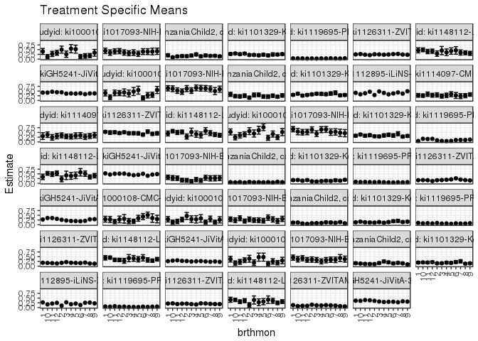

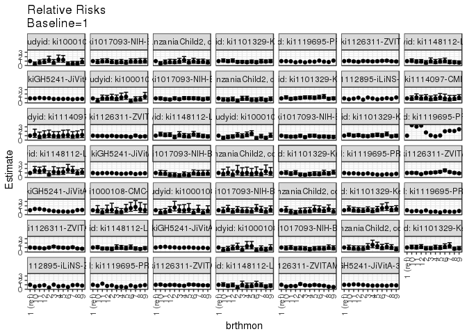

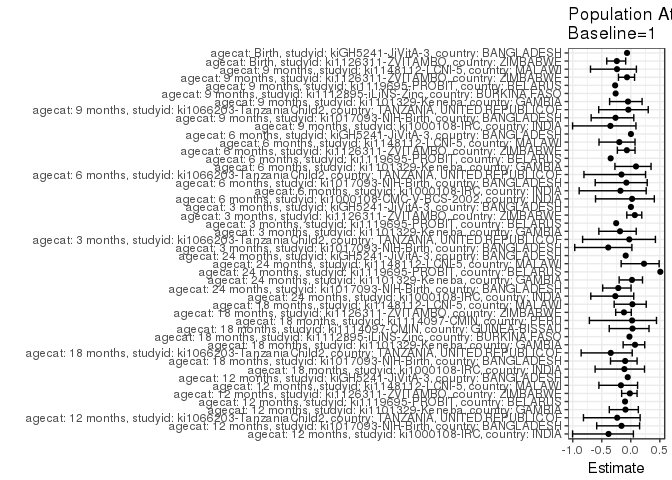

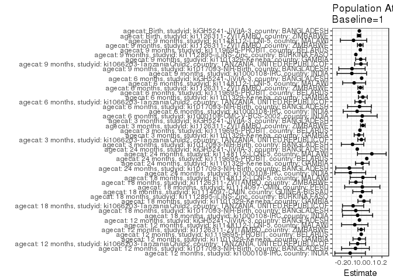

## Results Table

### Parameter: TSM

| agecat | studyid | country | intervention_level | baseline_level | estimate | ci_lower | ci_upper |
| --- | --- | --- | --- | --- | --- | --- | --- |
| Birth | ki1126311-ZVITAMBO | ZIMBABWE | 1 | NA | 0.1284541 | 0.1105318 | 0.1463763 |
| Birth | ki1126311-ZVITAMBO | ZIMBABWE | 2 | NA | 0.1506196 | 0.1289741 | 0.1722652 |
| Birth | ki1126311-ZVITAMBO | ZIMBABWE | 3 | NA | 0.1164797 | 0.0980102 | 0.1349492 |
| Birth | ki1126311-ZVITAMBO | ZIMBABWE | 4 | NA | 0.1102123 | 0.0906948 | 0.1297298 |
| Birth | ki1126311-ZVITAMBO | ZIMBABWE | 5 | NA | 0.1262327 | 0.1057905 | 0.1466750 |
| Birth | ki1126311-ZVITAMBO | ZIMBABWE | 6 | NA | 0.1145374 | 0.0960096 | 0.1330653 |
| Birth | ki1126311-ZVITAMBO | ZIMBABWE | 7 | NA | 0.1023018 | 0.0849589 | 0.1196447 |
| Birth | ki1126311-ZVITAMBO | ZIMBABWE | 8 | NA | 0.0742219 | 0.0597072 | 0.0887366 |
| Birth | ki1126311-ZVITAMBO | ZIMBABWE | 9 | NA | 0.0633205 | 0.0500558 | 0.0765851 |
| Birth | ki1126311-ZVITAMBO | ZIMBABWE | 10 | NA | 0.0798845 | 0.0633988 | 0.0963702 |
| Birth | ki1126311-ZVITAMBO | ZIMBABWE | 11 | NA | 0.0932994 | 0.0766967 | 0.1099021 |
| Birth | ki1126311-ZVITAMBO | ZIMBABWE | 12 | NA | 0.0928690 | 0.0764872 | 0.1092507 |
| Birth | kiGH5241-JiVitA-3 | BANGLADESH | 1 | NA | 0.3633406 | NA | NA |
| Birth | kiGH5241-JiVitA-3 | BANGLADESH | 2 | NA | 0.3554054 | NA | NA |
| Birth | kiGH5241-JiVitA-3 | BANGLADESH | 3 | NA | 0.3193370 | NA | NA |
| Birth | kiGH5241-JiVitA-3 | BANGLADESH | 4 | NA | 0.2940276 | NA | NA |
| Birth | kiGH5241-JiVitA-3 | BANGLADESH | 5 | NA | 0.3016194 | NA | NA |
| Birth | kiGH5241-JiVitA-3 | BANGLADESH | 6 | NA | 0.3063241 | NA | NA |
| Birth | kiGH5241-JiVitA-3 | BANGLADESH | 7 | NA | 0.2821497 | NA | NA |
| Birth | kiGH5241-JiVitA-3 | BANGLADESH | 8 | NA | 0.3286979 | NA | NA |
| Birth | kiGH5241-JiVitA-3 | BANGLADESH | 9 | NA | 0.3137255 | NA | NA |
| Birth | kiGH5241-JiVitA-3 | BANGLADESH | 10 | NA | 0.3578067 | NA | NA |
| Birth | kiGH5241-JiVitA-3 | BANGLADESH | 11 | NA | 0.3970856 | NA | NA |
| Birth | kiGH5241-JiVitA-3 | BANGLADESH | 12 | NA | 0.3837535 | NA | NA |
| 3 months | ki1017093-NIH-Birth | BANGLADESH | 1 | NA | 0.3166667 | 0.1988596 | 0.4344737 |
| 3 months | ki1017093-NIH-Birth | BANGLADESH | 2 | NA | 0.1568627 | 0.0569655 | 0.2567600 |
| 3 months | ki1017093-NIH-Birth | BANGLADESH | 3 | NA | 0.1132075 | 0.0278307 | 0.1985844 |
| 3 months | ki1017093-NIH-Birth | BANGLADESH | 4 | NA | 0.1956522 | 0.0809122 | 0.3103921 |
| 3 months | ki1017093-NIH-Birth | BANGLADESH | 5 | NA | 0.1521739 | 0.0482839 | 0.2560640 |
| 3 months | ki1017093-NIH-Birth | BANGLADESH | 6 | NA | 0.2954545 | 0.1605263 | 0.4303828 |

[output cut: 546 more lines]

### Parameter: E(Y)

| agecat | studyid | country | intervention_level | baseline_level | estimate | ci_lower | ci_upper |
| --- | --- | --- | --- | --- | --- | --- | --- |
| Birth | ki1126311-ZVITAMBO | ZIMBABWE | NA | NA | 0.1035430 | 0.0984652 | 0.1086208 |
| Birth | kiGH5241-JiVitA-3 | BANGLADESH | NA | NA | 0.3412682 | NA | NA |
| 3 months | ki1017093-NIH-Birth | BANGLADESH | NA | NA | 0.2280702 | 0.1935943 | 0.2625460 |
| 3 months | ki1066203-TanzaniaChild2 | TANZANIA, UNITED REPUBLIC OF | NA | NA | 0.0597731 | 0.0500657 | 0.0694806 |
| 3 months | ki1101329-Keneba | GAMBIA | NA | NA | 0.1442922 | 0.1295722 | 0.1590123 |
| 3 months | ki1119695-PROBIT | BELARUS | NA | NA | 0.0628025 | NA | NA |
| 3 months | ki1126311-ZVITAMBO | ZIMBABWE | NA | NA | 0.1780703 | 0.1702494 | 0.1858912 |
| 3 months | kiGH5241-JiVitA-3 | BANGLADESH | NA | NA | 0.2767980 | NA | NA |
| 6 months | ki1000108-CMC-V-BCS-2002 | INDIA | NA | NA | 0.3008130 | 0.2539566 | 0.3476694 |
| 6 months | ki1000108-IRC | INDIA | NA | NA | 0.2457002 | 0.2038248 | 0.2875757 |
| 6 months | ki1017093-NIH-Birth | BANGLADESH | NA | NA | 0.2681564 | 0.2306532 | 0.3056597 |
| 6 months | ki1066203-TanzaniaChild2 | TANZANIA, UNITED REPUBLIC OF | NA | NA | 0.0970922 | 0.0842059 | 0.1099785 |
| 6 months | ki1101329-Keneba | GAMBIA | NA | NA | 0.1412159 | 0.1262788 | 0.1561530 |
| 6 months | ki1119695-PROBIT | BELARUS | NA | NA | 0.0713633 | NA | NA |
| 6 months | ki1126311-ZVITAMBO | ZIMBABWE | NA | NA | 0.1662447 | 0.1582324 | 0.1742571 |
| 6 months | ki1148112-LCNI-5 | MALAWI | NA | NA | 0.3682956 | 0.3356382 | 0.4009530 |
| 6 months | kiGH5241-JiVitA-3 | BANGLADESH | NA | NA | 0.2618103 | NA | NA |
| 9 months | ki1000108-IRC | INDIA | NA | NA | 0.2727273 | 0.2294063 | 0.3160482 |
| 9 months | ki1017093-NIH-Birth | BANGLADESH | NA | NA | 0.3570020 | 0.3152562 | 0.3987478 |
| 9 months | ki1066203-TanzaniaChild2 | TANZANIA, UNITED REPUBLIC OF | NA | NA | 0.1482103 | 0.1317366 | 0.1646840 |
| 9 months | ki1101329-Keneba | GAMBIA | NA | NA | 0.1799710 | 0.1634057 | 0.1965363 |
| 9 months | ki1112895-iLiNS-Zinc | BURKINA FASO | NA | NA | 0.2152231 | NA | NA |
| 9 months | ki1119695-PROBIT | BELARUS | NA | NA | 0.0449018 | NA | NA |
| 9 months | ki1126311-ZVITAMBO | ZIMBABWE | NA | NA | 0.1979153 | 0.1890010 | 0.2068296 |
| 9 months | ki1148112-LCNI-5 | MALAWI | NA | NA | 0.3328313 | 0.2969622 | 0.3687005 |
| 12 months | ki1000108-IRC | INDIA | NA | NA | 0.2931034 | 0.2487723 | 0.3374346 |
| 12 months | ki1017093-NIH-Birth | BANGLADESH | NA | NA | 0.3747454 | 0.3318860 | 0.4176049 |
| 12 months | ki1066203-TanzaniaChild2 | TANZANIA, UNITED REPUBLIC OF | NA | NA | 0.1655125 | 0.1463373 | 0.1846877 |
| 12 months | ki1101329-Keneba | GAMBIA | NA | NA | 0.2479466 | 0.2287657 | 0.2671275 |
| 12 months | ki1119695-PROBIT | BELARUS | NA | NA | 0.0341262 | NA | NA |
| 12 months | ki1126311-ZVITAMBO | ZIMBABWE | NA | NA | 0.2444807 | 0.2342264 | 0.2547350 |
| 12 months | ki1148112-LCNI-5 | MALAWI | NA | NA | 0.3945687 | 0.3562508 | 0.4328866 |
| 12 months | kiGH5241-JiVitA-3 | BANGLADESH | NA | NA | 0.3967814 | NA | NA |
| 18 months | ki1000108-IRC | INDIA | NA | NA | 0.3555556 | 0.3088785 | 0.4022327 |
| 18 months | ki1017093-NIH-Birth | BANGLADESH | NA | NA | 0.5874730 | 0.5425832 | 0.6323628 |
| 18 months | ki1066203-TanzaniaChild2 | TANZANIA, UNITED REPUBLIC OF | NA | NA | 0.2408163 | 0.2140325 | 0.2676002 |
| 18 months | ki1101329-Keneba | GAMBIA | NA | NA | 0.3224129 | 0.3015170 | 0.3433088 |
| 18 months | ki1112895-iLiNS-Zinc | BURKINA FASO | NA | NA | 0.3944354 | NA | NA |
| 18 months | ki1114097-CMIN | GUINEA-BISSAU | NA | NA | 0.2811671 | 0.2490566 | 0.3132776 |
| 18 months | ki1114097-CMIN | PERU | NA | NA | 0.3149284 | 0.2737175 | 0.3561393 |
| 18 months | ki1126311-ZVITAMBO | ZIMBABWE | NA | NA | 0.4754386 | 0.4517618 | 0.4991154 |
| 18 months | ki1148112-LCNI-5 | MALAWI | NA | NA | 0.4593103 | 0.4230104 | 0.4956103 |
| 24 months | ki1000108-IRC | INDIA | NA | NA | 0.4156479 | 0.3678270 | 0.4634689 |
| 24 months | ki1017093-NIH-Birth | BANGLADESH | NA | NA | 0.5547786 | 0.5076945 | 0.6018626 |
| 24 months | ki1101329-Keneba | GAMBIA | NA | NA | 0.3344928 | 0.3122213 | 0.3567642 |
| 24 months | ki1119695-PROBIT | BELARUS | NA | NA | 0.1000618 | NA | NA |
| 24 months | ki1148112-LCNI-5 | MALAWI | NA | NA | 0.4421416 | 0.4016536 | 0.4826297 |
| 24 months | kiGH5241-JiVitA-3 | BANGLADESH | NA | NA | 0.4814815 | NA | NA |

### Parameter: RR

| agecat | studyid | country | intervention_level | baseline_level | estimate | ci_lower | ci_upper |
| --- | --- | --- | --- | --- | --- | --- | --- |
| Birth | ki1126311-ZVITAMBO | ZIMBABWE | 1 | 1 | 1.0000000 | 1.0000000 | 1.0000000 |
| Birth | ki1126311-ZVITAMBO | ZIMBABWE | 2 | 1 | 1.1725564 | 0.9597224 | 1.4325897 |
| Birth | ki1126311-ZVITAMBO | ZIMBABWE | 3 | 1 | 0.9067811 | 0.7341345 | 1.1200291 |
| Birth | ki1126311-ZVITAMBO | ZIMBABWE | 4 | 1 | 0.8579902 | 0.6848113 | 1.0749635 |
| Birth | ki1126311-ZVITAMBO | ZIMBABWE | 5 | 1 | 0.9827072 | 0.7935810 | 1.2169059 |
| Birth | ki1126311-ZVITAMBO | ZIMBABWE | 6 | 1 | 0.8916607 | 0.7201543 | 1.1040118 |
| Birth | ki1126311-ZVITAMBO | ZIMBABWE | 7 | 1 | 0.7964075 | 0.6394143 | 0.9919468 |
| Birth | ki1126311-ZVITAMBO | ZIMBABWE | 8 | 1 | 0.5778086 | 0.4544167 | 0.7347063 |
| Birth | ki1126311-ZVITAMBO | ZIMBABWE | 9 | 1 | 0.4929424 | 0.3832538 | 0.6340245 |
| Birth | ki1126311-ZVITAMBO | ZIMBABWE | 10 | 1 | 0.6218916 | 0.4847616 | 0.7978130 |
| Birth | ki1126311-ZVITAMBO | ZIMBABWE | 11 | 1 | 0.7263250 | 0.5793296 | 0.9106181 |
| Birth | ki1126311-ZVITAMBO | ZIMBABWE | 12 | 1 | 0.7229743 | 0.5773615 | 0.9053111 |
| Birth | kiGH5241-JiVitA-3 | BANGLADESH | 1 | 1 | 1.0000000 | NA | NA |
| Birth | kiGH5241-JiVitA-3 | BANGLADESH | 2 | 1 | 0.9781605 | NA | NA |
| Birth | kiGH5241-JiVitA-3 | BANGLADESH | 3 | 1 | 0.8788917 | NA | NA |
| Birth | kiGH5241-JiVitA-3 | BANGLADESH | 4 | 1 | 0.8092341 | NA | NA |
| Birth | kiGH5241-JiVitA-3 | BANGLADESH | 5 | 1 | 0.8301287 | NA | NA |
| Birth | kiGH5241-JiVitA-3 | BANGLADESH | 6 | 1 | 0.8430771 | NA | NA |
| Birth | kiGH5241-JiVitA-3 | BANGLADESH | 7 | 1 | 0.7765434 | NA | NA |
| Birth | kiGH5241-JiVitA-3 | BANGLADESH | 8 | 1 | 0.9046550 | NA | NA |
| Birth | kiGH5241-JiVitA-3 | BANGLADESH | 9 | 1 | 0.8634475 | NA | NA |
| Birth | kiGH5241-JiVitA-3 | BANGLADESH | 10 | 1 | 0.9847695 | NA | NA |
| Birth | kiGH5241-JiVitA-3 | BANGLADESH | 11 | 1 | 1.0928744 | NA | NA |
| Birth | kiGH5241-JiVitA-3 | BANGLADESH | 12 | 1 | 1.0561813 | NA | NA |
| 3 months | ki1017093-NIH-Birth | BANGLADESH | 1 | 1 | 1.0000000 | 1.0000000 | 1.0000000 |
| 3 months | ki1017093-NIH-Birth | BANGLADESH | 2 | 1 | 0.4953560 | 0.2369223 | 1.0356879 |
| 3 months | ki1017093-NIH-Birth | BANGLADESH | 3 | 1 | 0.3574975 | 0.1541922 | 0.8288649 |
| 3 months | ki1017093-NIH-Birth | BANGLADESH | 4 | 1 | 0.6178490 | 0.3085085 | 1.2373640 |
| 3 months | ki1017093-NIH-Birth | BANGLADESH | 5 | 1 | 0.4805492 | 0.2208406 | 1.0456751 |
| 3 months | ki1017093-NIH-Birth | BANGLADESH | 6 | 1 | 0.9330144 | 0.5176968 | 1.6815167 |

[output cut: 546 more lines]

### Parameter: PAR

| agecat | studyid | country | intervention_level | baseline_level | estimate | ci_lower | ci_upper |
| --- | --- | --- | --- | --- | --- | --- | --- |
| Birth | ki1126311-ZVITAMBO | ZIMBABWE | 1 | NA | -0.0249110 | -0.0417869 | -0.0080352 |
| Birth | kiGH5241-JiVitA-3 | BANGLADESH | 1 | NA | -0.0220724 | NA | NA |
| 3 months | ki1017093-NIH-Birth | BANGLADESH | 1 | NA | -0.0885965 | -0.1988022 | 0.0216092 |
| 3 months | ki1066203-TanzaniaChild2 | TANZANIA, UNITED REPUBLIC OF | 1 | NA | -0.0015766 | -0.0370569 | 0.0339037 |
| 3 months | ki1101329-Keneba | GAMBIA | 1 | NA | -0.0267604 | -0.0726855 | 0.0191647 |
| 3 months | ki1119695-PROBIT | BELARUS | 1 | NA | -0.0158265 | NA | NA |
| 3 months | ki1126311-ZVITAMBO | ZIMBABWE | 1 | NA | 0.0123124 | -0.0105991 | 0.0352238 |
| 3 months | kiGH5241-JiVitA-3 | BANGLADESH | 1 | NA | 0.0006919 | NA | NA |
| 6 months | ki1000108-CMC-V-BCS-2002 | INDIA | 1 | NA | 0.0066954 | -0.1395296 | 0.1529203 |
| 6 months | ki1000108-IRC | INDIA | 1 | NA | -0.0437734 | -0.1805392 | 0.0929924 |
| 6 months | ki1017093-NIH-Birth | BANGLADESH | 1 | NA | -0.0203051 | -0.1371620 | 0.0965518 |
| 6 months | ki1066203-TanzaniaChild2 | TANZANIA, UNITED REPUBLIC OF | 1 | NA | -0.0155839 | -0.0655172 | 0.0343495 |
| 6 months | ki1101329-Keneba | GAMBIA | 1 | NA | 0.0126445 | -0.0304991 | 0.0557880 |
| 6 months | ki1119695-PROBIT | BELARUS | 1 | NA | -0.0247512 | NA | NA |
| 6 months | ki1126311-ZVITAMBO | ZIMBABWE | 1 | NA | -0.0113371 | -0.0365480 | 0.0138737 |
| 6 months | ki1148112-LCNI-5 | MALAWI | 1 | NA | -0.0728809 | -0.1857983 | 0.0400365 |
| 6 months | kiGH5241-JiVitA-3 | BANGLADESH | 1 | NA | 0.0006163 | NA | NA |
| 9 months | ki1000108-IRC | INDIA | 1 | NA | -0.0956938 | -0.2407936 | 0.0494061 |
| 9 months | ki1017093-NIH-Birth | BANGLADESH | 1 | NA | -0.0939784 | -0.2230901 | 0.0351333 |
| 9 months | ki1066203-TanzaniaChild2 | TANZANIA, UNITED REPUBLIC OF | 1 | NA | -0.0062613 | -0.0678345 | 0.0553120 |
| 9 months | ki1101329-Keneba | GAMBIA | 1 | NA | -0.0087083 | -0.0585109 | 0.0410943 |
| 9 months | ki1112895-iLiNS-Zinc | BURKINA FASO | 1 | NA | -0.0562055 | NA | NA |
| 9 months | ki1119695-PROBIT | BELARUS | 1 | NA | -0.0121158 | NA | NA |
| 9 months | ki1126311-ZVITAMBO | ZIMBABWE | 1 | NA | -0.0128177 | -0.0401919 | 0.0145566 |
| 9 months | ki1148112-LCNI-5 | MALAWI | 1 | NA | -0.0789334 | -0.2083612 | 0.0504945 |
| 12 months | ki1000108-IRC | INDIA | 1 | NA | -0.1123020 | -0.2622387 | 0.0376348 |
| 12 months | ki1017093-NIH-Birth | BANGLADESH | 1 | NA | -0.0600372 | -0.1962280 | 0.0761537 |
| 12 months | ki1066203-TanzaniaChild2 | TANZANIA, UNITED REPUBLIC OF | 1 | NA | -0.0387886 | -0.1176658 | 0.0400886 |
| 12 months | ki1101329-Keneba | GAMBIA | 1 | NA | -0.0227716 | -0.0842627 | 0.0387195 |
| 12 months | ki1119695-PROBIT | BELARUS | 1 | NA | -0.0033738 | NA | NA |
| 12 months | ki1126311-ZVITAMBO | ZIMBABWE | 1 | NA | -0.0039064 | -0.0363022 | 0.0284893 |
| 12 months | ki1148112-LCNI-5 | MALAWI | 1 | NA | -0.0669698 | -0.1965920 | 0.0626525 |
| 12 months | kiGH5241-JiVitA-3 | BANGLADESH | 1 | NA | -0.0209818 | NA | NA |
| 18 months | ki1000108-IRC | INDIA | 1 | NA | -0.0391813 | -0.1869906 | 0.1086281 |
| 18 months | ki1017093-NIH-Birth | BANGLADESH | 1 | NA | -0.0569714 | -0.1904155 | 0.0764726 |
| 18 months | ki1066203-TanzaniaChild2 | TANZANIA, UNITED REPUBLIC OF | 1 | NA | -0.0831273 | -0.1873388 | 0.0210841 |
| 18 months | ki1101329-Keneba | GAMBIA | 1 | NA | 0.0233933 | -0.0361706 | 0.0829572 |
| 18 months | ki1112895-iLiNS-Zinc | BURKINA FASO | 1 | NA | -0.0090734 | NA | NA |
| 18 months | ki1114097-CMIN | GUINEA-BISSAU | 1 | NA | 0.0084398 | -0.0859838 | 0.1028635 |
| 18 months | ki1114097-CMIN | PERU | 1 | NA | 0.0072361 | -0.1656285 | 0.1801008 |
| 18 months | ki1126311-ZVITAMBO | ZIMBABWE | 1 | NA | -0.0559624 | -0.1197196 | 0.0077948 |
| 18 months | ki1148112-LCNI-5 | MALAWI | 1 | NA | 0.0128818 | -0.1123026 | 0.1380661 |
| 24 months | ki1000108-IRC | INDIA | 1 | NA | -0.1106679 | -0.2618523 | 0.0405166 |
| 24 months | ki1017093-NIH-Birth | BANGLADESH | 1 | NA | -0.1196400 | -0.2535708 | 0.0142907 |
| 24 months | ki1101329-Keneba | GAMBIA | 1 | NA | 0.0070074 | -0.0598133 | 0.0738280 |
| 24 months | ki1119695-PROBIT | BELARUS | 1 | NA | 0.0508814 | NA | NA |
| 24 months | ki1148112-LCNI-5 | MALAWI | 1 | NA | 0.1006782 | -0.0398757 | 0.2412321 |
| 24 months | kiGH5241-JiVitA-3 | BANGLADESH | 1 | NA | -0.0421872 | NA | NA |

### Parameter: PAF

| agecat | studyid | country | intervention_level | baseline_level | estimate | ci_lower | ci_upper |
| --- | --- | --- | --- | --- | --- | --- | --- |
| Birth | ki1126311-ZVITAMBO | ZIMBABWE | 1 | NA | -0.2405864 | -0.4144133 | -0.0881224 |
| Birth | kiGH5241-JiVitA-3 | BANGLADESH | 1 | NA | -0.0646774 | NA | NA |
| 3 months | ki1017093-NIH-Birth | BANGLADESH | 1 | NA | -0.3884615 | -0.9655117 | 0.0191737 |
| 3 months | ki1066203-TanzaniaChild2 | TANZANIA, UNITED REPUBLIC OF | 1 | NA | -0.0263759 | -0.8300620 | 0.4243652 |
| 3 months | ki1101329-Keneba | GAMBIA | 1 | NA | -0.1854597 | -0.5501180 | 0.0934144 |
| 3 months | ki1119695-PROBIT | BELARUS | 1 | NA | -0.2520042 | NA | NA |
| 3 months | ki1126311-ZVITAMBO | ZIMBABWE | 1 | NA | 0.0691433 | -0.0688140 | 0.1892937 |
| 3 months | kiGH5241-JiVitA-3 | BANGLADESH | 1 | NA | 0.0024995 | NA | NA |
| 6 months | ki1000108-CMC-V-BCS-2002 | INDIA | 1 | NA | 0.0222576 | -0.6074578 | 0.4052843 |
| 6 months | ki1000108-IRC | INDIA | 1 | NA | -0.1781579 | -0.8893869 | 0.2653405 |
| 6 months | ki1017093-NIH-Birth | BANGLADESH | 1 | NA | -0.0757212 | -0.6129583 | 0.2825754 |
| 6 months | ki1066203-TanzaniaChild2 | TANZANIA, UNITED REPUBLIC OF | 1 | NA | -0.1605062 | -0.8071109 | 0.2547360 |
| 6 months | ki1101329-Keneba | GAMBIA | 1 | NA | 0.0895400 | -0.2733388 | 0.3490048 |
| 6 months | ki1119695-PROBIT | BELARUS | 1 | NA | -0.3468333 | NA | NA |
| 6 months | ki1126311-ZVITAMBO | ZIMBABWE | 1 | NA | -0.0681955 | -0.2311134 | 0.0731629 |
| 6 months | ki1148112-LCNI-5 | MALAWI | 1 | NA | -0.1978869 | -0.5475477 | 0.0727697 |
| 6 months | kiGH5241-JiVitA-3 | BANGLADESH | 1 | NA | 0.0023539 | NA | NA |
| 9 months | ki1000108-IRC | INDIA | 1 | NA | -0.3508772 | -1.0029579 | 0.0889129 |
| 9 months | ki1017093-NIH-Birth | BANGLADESH | 1 | NA | -0.2632434 | -0.6826856 | 0.0516446 |
| 9 months | ki1066203-TanzaniaChild2 | TANZANIA, UNITED REPUBLIC OF | 1 | NA | -0.0422457 | -0.5526561 | 0.3003755 |
| 9 months | ki1101329-Keneba | GAMBIA | 1 | NA | -0.0483871 | -0.3650462 | 0.1948145 |
| 9 months | ki1112895-iLiNS-Zinc | BURKINA FASO | 1 | NA | -0.2611498 | NA | NA |
| 9 months | ki1119695-PROBIT | BELARUS | 1 | NA | -0.2698282 | NA | NA |
| 9 months | ki1126311-ZVITAMBO | ZIMBABWE | 1 | NA | -0.0647634 | -0.2124452 | 0.0649300 |
| 9 months | ki1148112-LCNI-5 | MALAWI | 1 | NA | -0.2371573 | -0.6943515 | 0.0966702 |
| 12 months | ki1000108-IRC | INDIA | 1 | NA | -0.3831479 | -1.0028169 | 0.0447964 |
| 12 months | ki1017093-NIH-Birth | BANGLADESH | 1 | NA | -0.1602079 | -0.5872354 | 0.1519327 |
| 12 months | ki1066203-TanzaniaChild2 | TANZANIA, UNITED REPUBLIC OF | 1 | NA | -0.2343546 | -0.8154102 | 0.1607234 |
| 12 months | ki1101329-Keneba | GAMBIA | 1 | NA | -0.0918408 | -0.3702312 | 0.1299889 |
| 12 months | ki1119695-PROBIT | BELARUS | 1 | NA | -0.0988636 | NA | NA |
| 12 months | ki1126311-ZVITAMBO | ZIMBABWE | 1 | NA | -0.0159785 | -0.1575156 | 0.1082520 |
| 12 months | ki1148112-LCNI-5 | MALAWI | 1 | NA | -0.1697291 | -0.5493039 | 0.1168511 |
| 12 months | kiGH5241-JiVitA-3 | BANGLADESH | 1 | NA | -0.0528800 | NA | NA |
| 18 months | ki1000108-IRC | INDIA | 1 | NA | -0.1101974 | -0.6145224 | 0.2365927 |
| 18 months | ki1017093-NIH-Birth | BANGLADESH | 1 | NA | -0.0969771 | -0.3496707 | 0.1084056 |
| 18 months | ki1066203-TanzaniaChild2 | TANZANIA, UNITED REPUBLIC OF | 1 | NA | -0.3451898 | -0.8552987 | 0.0246662 |
| 18 months | ki1101329-Keneba | GAMBIA | 1 | NA | 0.0725569 | -0.1318640 | 0.2400583 |
| 18 months | ki1112895-iLiNS-Zinc | BURKINA FASO | 1 | NA | -0.0230036 | NA | NA |
| 18 months | ki1114097-CMIN | GUINEA-BISSAU | 1 | NA | 0.0300172 | -0.3712721 | 0.3138731 |
| 18 months | ki1114097-CMIN | PERU | 1 | NA | 0.0229770 | -0.7135446 | 0.4429244 |
| 18 months | ki1126311-ZVITAMBO | ZIMBABWE | 1 | NA | -0.1177068 | -0.2603332 | 0.0087791 |
| 18 months | ki1148112-LCNI-5 | MALAWI | 1 | NA | 0.0280459 | -0.2865603 | 0.2657206 |
| 24 months | ki1000108-IRC | INDIA | 1 | NA | -0.2662539 | -0.6889862 | 0.0506738 |
| 24 months | ki1017093-NIH-Birth | BANGLADESH | 1 | NA | -0.2156537 | -0.4844196 | 0.0044500 |
| 24 months | ki1101329-Keneba | GAMBIA | 1 | NA | 0.0209493 | -0.2006579 | 0.2016541 |
| 24 months | ki1119695-PROBIT | BELARUS | 1 | NA | 0.5085003 | NA | NA |
| 24 months | ki1148112-LCNI-5 | MALAWI | 1 | NA | 0.2277058 | -0.1658272 | 0.4883990 |
| 24 months | kiGH5241-JiVitA-3 | BANGLADESH | 1 | NA | -0.0876195 | NA | NA |